# Sales prediction model for State of Connecticut Real Estate Sales 2001-2022 GL

The Office of Policy and Management maintains a listing of all real estate sales with a sales price of $2,000 or greater that occur between October 1 and September 30 of each year. For each sale record, the file includes: town, property address, date of sale, property type (residential, apartment, commercial, industrial or vacant land), sales price, and property assessment.

Source Data : https://catalog.data.gov/dataset/real-estate-sales-2001-2018

Return Home : https://johnkimaiyo.vercel.app/

Creating a prediction model using Python and Pandas involves several steps, including data preprocessing, exploratory data analysis, feature engineering, model selection, training, and evaluation.

## Step 1: Import Necessary Libraries

```python
import pandas as pd
import numpy as np
from sklearn.model_selection import train_test_split
from sklearn.linear_model import LinearRegression
from sklearn.metrics import mean_squared_error
import matplotlib.pyplot as plt
import joblib
```

## Step 2: Load the Dataset

```python
Real_Estate_Sales_df = pd.read_csv(r"C:\Users\jki\Desktop\Data Scence Projects\Sate of Connecticut Real Etstae Sales\Machine Learning\Source Data\Real_Estate_Sales_2001-2022_GL.csv")

# Display the first few rows of the dataset
print(Real_Estate_Sales_df.head())
```

```
   Serial Number  List Year Date Recorded     Town           Address  \
0         220008       2022    01/30/2023  Andover       618 ROUTE 6
1        2020348       2020    09/13/2021  Ansonia   230 WAKELEE AVE
2          20002       2020    10/02/2020  Ashford   390 TURNPIKE RD
3         210317       2021    07/05/2022     Avon   53 COTSWOLD WAY
4         200212       2020    03/09/2021     Avon  5 CHESTNUT DRIVE

   Assessed Value  Sale Amount  Sales Ratio Property Type Residential Type  \
0        139020.0     232000.0       0.5992   Residential    Single Family
1        150500.0     325000.0       0.4630    Commercial              NaN
2        253000.0     430000.0       0.5883   Residential    Single Family
3        329730.0     805000.0       0.4096   Residential    Single Family
4        130400.0     179900.0       0.7248   Residential            Condo

  Non Use Code Assessor Remarks OPM remarks  \
0          NaN              NaN         NaN
1          NaN              NaN         NaN
2          NaN              NaN         NaN
3          NaN              NaN         NaN
4          NaN              NaN         NaN

                             Location
0  POINT (-72.343628962 41.728431984)
1                                 NaN
2                                 NaN
3  POINT (-72.846365959 41.781677018)
4                                 NaN
```

## Step 3: Data Preprocessing

Before building the model, you need to preprocess the data. This includes handling missing values, converting data types, and encoding categorical variables if necessary.

```python
# lets check for  missing values
missing_values =  Real_Estate_Sales_df.isna().sum()
print(missing_values)
```

```
Serial Number             0
List Year                 0
Date Recorded             2
Town                      0
Address                  51
Assessed Value            0
Sale Amount               0
Sales Ratio               0
Property Type        382446
Residential Type     398389
Non Use Code         784178
Assessor Remarks     926401
OPM remarks         1084598
Location             799518
dtype: int64
```

```python
# lets remove missing values
Real_Estate_Sales_df.dropna(subset=['Date Recorded','Address','Property Type','Residential Type','Non Use Code','Assessor Remarks','OPM remarks','Location'],inplace =True)
# lets confirm existance of missing values
missing_values = Real_Estate_Sales_df.isna().sum()
print(missing_values)
```

```
Serial Number       0
List Year           0
Date Recorded       0
Town                0
Address             0
Assessed Value      0
Sale Amount         0
Sales Ratio         0
Property Type       0
Residential Type    0
Non Use Code        0
Assessor Remarks    0
OPM remarks         0
Location            0
dtype: int64
```

```python
# let check if we have unwanted negative values
Real_Estate_Sales_df.describe()
```

[output not shown]

```python
# lets check for data types to perform numerical calculations
Real_Estate_Sales_df.info()
```

[output not shown]

```python
print(Real_Estate_Sales_df.columns)
```

[output not shown]

```python
# lets drop unwanted columns

# Columns to drop
columns_to_drop = ['Property Type', 'Residential Type','Non Use Code','Assessor Remarks','OPM remarks','Location','Address','Town','Serial Number','List Year']
Real_Estate_Sales_df.drop(columns=columns_to_drop, inplace=True,errors='ignore')
Real_Estate_Sales_df.head(5)
```

[output not shown]

## Step 4: Exploratory Data Analysis (EDA)

```
       Assessed Value   Sale Amount  Sales Ratio         Year       Month  \
count    5.600000e+02  5.600000e+02   560.000000   560.000000  560.000000
mean     1.701261e+05  9.091623e+05     0.838064  2020.926786    6.951786
std      1.669984e+05  1.346897e+07     1.091531     1.850397    3.215486
min      0.000000e+00  4.500000e+03     0.000000  2017.000000    1.000000
25%      9.025750e+04  1.100000e+05     0.413374  2020.000000    4.000000
50%      1.416000e+05  2.140000e+05     0.625957  2021.000000    7.000000
75%      1.992075e+05  3.752500e+05     1.020047  2022.000000   10.000000
max      2.083410e+06  3.187900e+08    20.020000  2023.000000   12.000000

              Day
count  560.000000
mean    15.817857
std      9.149467
min      1.000000
25%      8.000000
50%     17.000000
75%     23.000000
max     31.000000
                Assessed Value  Sale Amount  Sales Ratio      Year     Month  \
Assessed Value        1.000000     0.048048    -0.046309  0.017759 -0.014153
Sale Amount           0.048048     1.000000    -0.040326  0.004436 -0.000965
Sales Ratio          -0.046309    -0.040326     1.000000 -0.008175  0.013997
Year                  0.017759     0.004436    -0.008175  1.000000 -0.140702
Month                -0.014153    -0.000965     0.013997 -0.140702  1.000000
Day                  -0.026584    -0.045498     0.056925  0.012419  0.000674

                     Day
Assessed Value -0.026584
Sale Amount    -0.045498
Sales Ratio     0.056925
Year            0.012419
Month           0.000674
Day             1.000000
```

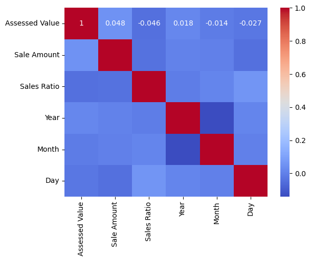

```python
# Summary statistics
print(Real_Estate_Sales_df.describe())

# Correlation matrix
print(Real_Estate_Sales_df.corr())

# Plotting the correlation matrix
import seaborn as sns
sns.heatmap(Real_Estate_Sales_df.corr(), annot=True, cmap='coolwarm')
plt.show()
```

## Step 5: Feature Engineering

```python
# Display the first few rows after feature engineering
print(Real_Estate_Sales_df.head())
```

```
      Assessed Value  Sale Amount  Sales Ratio  Year  Month  Day
527         207700.0     400000.0       0.5193  2023      9   20
922          49700.0      29900.0       1.6622  2023      2   27
940         208230.0     423261.0       0.4920  2022     10   31
1345        169050.0     351000.0       0.4816  2023      3   30
1632        769900.0    3500000.0       0.2200  2023      4   26
```

## Step 6: Splitting the Data

Split the data into training and testing sets

```python
# Define features (X) and target (y)
X = Real_Estate_Sales_df.drop(['Sale Amount'], axis=1)
y = Real_Estate_Sales_df['Sale Amount']

# Split the data into training and testing sets
X_train, X_test, y_train, y_test = train_test_split(X, y, test_size=0.2, random_state=42)

print(X_train.shape, X_test.shape)
```

```
(448, 5) (112, 5)
```

## Step 7: Model Selection and Training

```python
# Initialize the model
model = LinearRegression()

# Train the model
model.fit(X_train, y_train)
```

```
LinearRegression()
```

## Step 8: Model Evaluation

Evaluate the model's performance on the test data.

```
Mean Squared Error: 1358146224171.0066
```

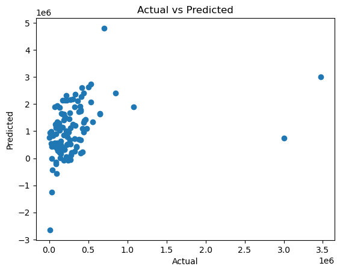

```python
# Make predictions
y_pred = model.predict(X_test)

# Calculate the Mean Squared Error (MSE)
mse = mean_squared_error(y_test, y_pred)
print(f'Mean Squared Error: {mse}')

# Plot the actual vs predicted values
plt.scatter(y_test, y_pred)
plt.xlabel('Actual')
plt.ylabel('Predicted')
plt.title('Actual vs Predicted')
plt.show()
```

## Step 9: Making Predictions

You can now use the trained model to make predictions on new data.

```python
# Example: Predict on new data
new_data = pd.DataFrame({

    'Assessed Value': [20770],

    'Sales Ratio': [0.5],
    'Year': [2026],
    'Month': [5],
    'Day': [15],

})

# Save the model to a file
joblib.dump(model, 'real_estate_sales_model.pkl')

predicted_sales = model.predict(new_data)
print(f'Predicted Total Sales: {predicted_sales[0]}')
```

```
Predicted Total Sales: 872499.7062873021
```